# 고급회귀분석 9장

2025-03-26

## 9.1 다항회귀모형

### (예 9.1)

```r
source("functions/mult_reg.R", echo = TRUE)
```

```
##
## > mult_reg = function(X, y, alpha = 0.05, coeff = TRUE) {
## +     library(glue)
## +     if (!is.matrix(X)) {
## +         stop("X는 행렬이어야 합니다.")
## +     }
## +     .... [TRUNCATED]
##
## > mult_test = function(C, m, X, X_r, y, y_r, alpha = 0.05,
## +     method = "one", coef = TRUE) {
## +     n = dim(X)[1]
## +     p = dim(X)[2]
## +     k = dim .... [TRUNCATED]
##
## > ASS_calc = function(X, y, index_sol, index_given = NA,
## +     coef = TRUE) {
## +     n = dim(X)[1]
## +     p = dim(X)[2]
## +     if (coef == TRUE) {
## +     .... [TRUNCATED]
##
## > standard_calc = function(X, y) {
## +     n = dim(X)[1]
## +     p = dim(X)[2]
## +     xbar = c(rep(0, p))
## +     for (j in 1:p) {
## +         xbar[j] = mean(X .... [TRUNCATED]
##
## > ortho_poly = function(X, k, coef = TRUE) {
## +     library(glue)
## +     n = dim(X)[1]
## +     p = dim(X)[2]
## +     d = X[2, 1] - X[1, 1]
## +     for (i in 1 .... [TRUNCATED]
```

```r
x = c(1, 1, 2, 2, 2, 3, 3, 4, 4, 4, 5, 5, 5, 6, 6, 6, 7, 7, 8, 8, 8, 9, 9, 10)
y = c(5, 6, 6, 7, 8, 7, 8, 7, 8, 9, 8, 9, 10, 8, 9, 10, 8, 9, 7, 8, 9, 7, 8, 7)
X = cbind(x) ; n = dim(X)[1] ; p = dim(X)[2]

mult_res = mult_reg(X, y, alpha = 0.05, coeff = TRUE)
```

```
##   요인    제곱합 자유도 평균제곱합     F값 F기각치
## 1 회귀  4.724947      1   4.724947 3.39609 4.30095
## 2 잔차 30.608386     22   1.391290      NA      NA
## 3   계 35.333333     23         NA      NA      NA
## SST = 35.3333333333334, SSR = 4.72494705633183, SSE = 30.6083862770016
## MSR = 4.72494705633183, MSE = 1.39129028531826
## F_0 = 3.3960900224722, F_alpha = 4.30094950177766
```

```r
beta_hat_mult = mult_res$beta_hat ; beta_hat_mult
```

```
##          [,1]
## one 6.9491741
## x   0.1697586
```

```r
x2 = x^2 ; X_k = cbind(X, x2)

poly_res = mult_reg(X_k, y, alpha = 0.05, coeff = TRUE)
```

```
##   요인   제곱합 자유도 평균제곱합      F값 F기각치
## 1 회귀 22.02791      2 11.0139549 17.38337  3.4668
## 2 잔차 13.30542     21  0.6335916       NA      NA
## 3   계 35.33333     23         NA       NA      NA
## SST = 35.3333333333334, SSR = 22.0279097564733, SSE = 13.3054235768601
## MSR = 11.0139548782367, MSE = 0.633591598898101
## F_0 = 17.3833663473307, F_alpha = 3.46680011154242
```

```r
beta_hat_poly = poly_res$beta_hat ; beta_hat_poly
```

```
##           [,1]
## one  4.2142537
## x    1.5438368
## x2  -0.1302107
```

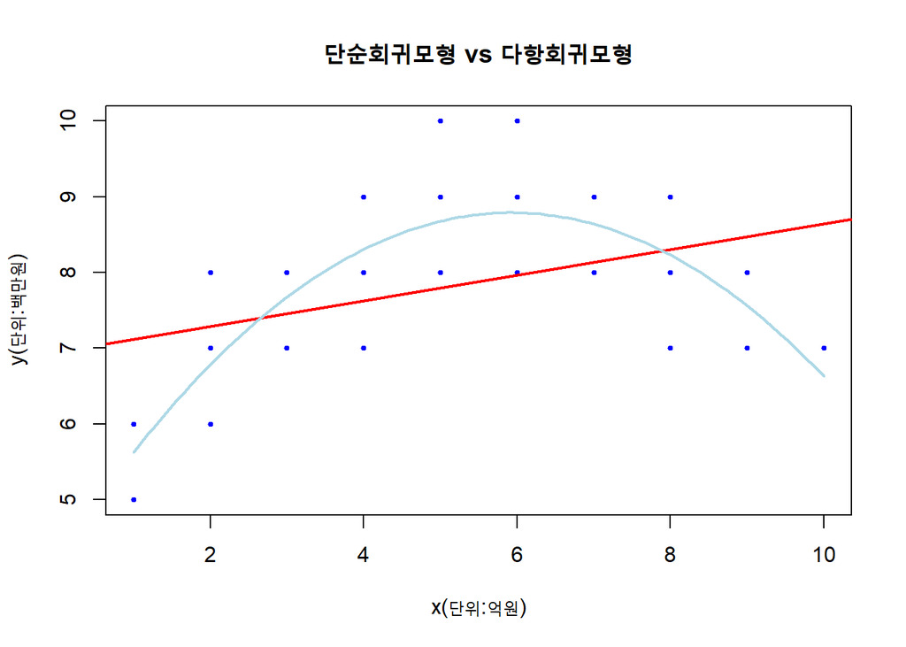

```r
plot(x, y, xlab = "x(단위:억원)", ylab = "y(단위:백만원)", col = "blue", cex = 0.5, pch = 19,
     main = "단순회귀모형 vs 다항회귀모형")
abline(coef = beta_hat_mult, lwd = 2, col = "red")
curve(beta_hat_poly[1] + beta_hat_poly[2] * x + beta_hat_poly[3] * x^2 , n = 101, add = TRUE, col = "lightblue", lwd = 2)
```

```r
beta_hat_poly[2] / (beta_hat_poly[3] * 2)
```

```
## [1] -5.928227
```

### (예 9.2)

```r
x1 = c(10, 20, 20, 40, 40, 50, 30, 30, 30, 30)
x2 = c(205, 213.66, 196.34, 213.66, 196.34, 205, 205, 205, 205, 205)
y = c(54.6, 71.7, 59.8, 78.7, 78.9, 91.0, 90.4, 87.5, 91.0, 88.3)

t1 = (x1 - 30)/20 ; t2 = (x2 - 205)/10
t1_sq = t1^2 ; t2_sq = t2^2 ; t1t2 = t1 * t2 ; X_T = cbind(t1, t2, t1_sq, t2_sq, t1t2)
n = dim(X_T)[1] ; p = dim(X_T)[2] ; X_T
```

```
##         t1     t2 t1_sq    t2_sq   t1t2
##  [1,] -1.0  0.000  1.00 0.000000  0.000
##  [2,] -0.5  0.866  0.25 0.749956 -0.433
##  [3,] -0.5 -0.866  0.25 0.749956  0.433
##  [4,]  0.5  0.866  0.25 0.749956  0.433
##  [5,]  0.5 -0.866  0.25 0.749956 -0.433
##  [6,]  1.0  0.000  1.00 0.000000  0.000
##  [7,]  0.0  0.000  0.00 0.000000  0.000
##  [8,]  0.0  0.000  0.00 0.000000  0.000
##  [9,]  0.0  0.000  0.00 0.000000  0.000
## [10,]  0.0  0.000  0.00 0.000000  0.000
```

```r
poly_res = mult_reg(X_T, y, alpha = 0.05, coeff = TRUE)
```

```
##   요인     제곱합 자유도 평균제곱합      F값  F기각치
## 1 회귀 1567.70733      5 313.541467 48.19698 6.256057
## 2 잔차   26.02167      4   6.505417       NA       NA
## 3   계 1593.72900      9         NA       NA       NA
## SST = 1593.729, SSR = 1567.70733333332, SSE = 26.0216666666795
## MSR = 313.541466666665, MSE = 6.50541666666986
## F_0 = 48.1969845641213, F_alpha = 6.25605650216089
```

```r
beta_hat = poly_res$beta_hat ; beta_hat
```

```
##             [,1]
## one    89.300000
## t1     16.483333
## t2      3.377598
## t1_sq -16.500000
## t2_sq -17.201009
## t1t2   -6.986143
```

```r
A = matrix(c(2*16.50, 6.99, 6.99, 2*17.20), nrow = 2) ; z = c(16.48, 3.38)

x = solve(A) %*% z  # x = solve(A, z) ; x
x
```

```
##              [,1]
## [1,]  0.500106642
## [2,] -0.003364693
```

```r
y_hat_star = t(c(1, x[1], x[2], (x[1])^2, (x[2])^2, x[1] * x[2])) %*% beta_hat ; y_hat_star
```

```
##          [,1]
## [1,] 93.41686
```

## 9.3 직교다항회귀

### (예 9.3)

```r
source("functions/mult_reg.R", echo = TRUE)
```

```
##
## > mult_reg = function(X, y, alpha = 0.05, coeff = TRUE) {
## +     library(glue)
## +     if (!is.matrix(X)) {
## +         stop("X는 행렬이어야 합니다.")
## +     }
## +     .... [TRUNCATED]
##
## > mult_test = function(C, m, X, X_r, y, y_r, alpha = 0.05,
## +     method = "one", coef = TRUE) {
## +     n = dim(X)[1]
## +     p = dim(X)[2]
## +     k = dim .... [TRUNCATED]
##
## > ASS_calc = function(X, y, index_sol, index_given = NA,
## +     coef = TRUE) {
## +     n = dim(X)[1]
## +     p = dim(X)[2]
## +     if (coef == TRUE) {
## +     .... [TRUNCATED]
##
## > standard_calc = function(X, y) {
## +     n = dim(X)[1]
## +     p = dim(X)[2]
## +     xbar = c(rep(0, p))
## +     for (j in 1:p) {
## +         xbar[j] = mean(X .... [TRUNCATED]
##
## > ortho_poly = function(X, k, coef = TRUE) {
## +     library(glue)
## +     n = dim(X)[1]
## +     p = dim(X)[2]
## +     d = X[2, 1] - X[1, 1]
## +     for (i in 1 .... [TRUNCATED]
```

```r
x = c(180, 200, 220, 240, 260, 280, 300)
y = c(82.0, 89.2, 94.5, 99.6, 102.5, 103.2, 103.8)
X = cbind(x)

X_p = ortho_poly(X, k = 2, coef = TRUE)
# t(X_p) %*% X_p ; t(X_p) %*% y

beta_hat = solve(t(X_p) %*% X_p) %*% t(X_p) %*% y ; beta_hat
```

```
##           [,1]
## one 96.4000000
## x^1  3.6214286
## x^2 -0.7190476
```

```r
X_ptX_p = t(X_p) %*% X_p ; X_ptX_p
```

```
##     one x^1 x^2
## one   7   0   0
## x^1   0  28   0
## x^2   0   0  84
```

```r
tX_py = t(X_p) %*% y ; tX_py
```

```
##      [,1]
## one 674.8
## x^1 101.4
## x^2 -60.4
```

```r
SS_betahat = t(beta_hat) %*% tX_py ; SS_betahat
```

```
##          [,1]
## [1,] 65461.36
```

```r
SS_beta1_beta0_hat = ASS_calc(X_p, y, index_sol = c(1), index_given = c(0), coef = FALSE)
```

```
## SS(beta_1 | beta_0) = 367.212857142862
```

```r
SS_beta2_beta0_hat = ASS_calc(X_p, y, index_sol = c(2), index_given = c(0), coef = FALSE)
```

```
## SS(beta_2 | beta_0) = 43.4304761904714
```

```r
SS_beta1_beta0_hat
```

```
##          [,1]
## [1,] 367.2129
```

```r
SS_beta2_beta0_hat
```

```
##          [,1]
## [1,] 43.43048
```

```r
## X_p 에서 절편항을 제거하고 mult_reg 함수 사용
X_p_ = X_p[, -c(1)]


mult_res = mult_reg(X_p_, y, alpha = 0.05, coef = TRUE)
```

```
##   요인      제곱합 자유도  평균제곱합      F값  F기각치
## 1 회귀 410.6433333      2 205.3216667 1331.816 6.944272
## 2 잔차   0.6166667      4   0.1541667       NA       NA
## 3   계 411.2600000      6          NA       NA       NA
## SST = 411.260000000007, SSR = 410.643333333335, SSE = 0.616666666669916
## MSR = 205.321666666668, MSE = 0.154166666667479
## F_0 = 1331.8162162092, F_alpha = 6.94427190999916
```

```r
F0_beta1_hat = SS_beta1_beta0_hat / mult_res$MSE ; F0_beta1_hat
```

```
##          [,1]
## [1,] 2381.921
```

```r
F0_beta2_hat = SS_beta2_beta0_hat / mult_res$MSE ; F0_beta2_hat
```

```
##          [,1]
## [1,] 281.7112
```

```r
F_alpha_1 = qf(0.05, 1, 7, lower.tail = FALSE) ; F_alpha_1
```

```
## [1] 5.591448
```

```r
## 삼차항에 대한 검정
X_p = ortho_poly(X, k = 3, coef = TRUE)

SS_beta1_beta0_hat = ASS_calc(X_p, y, index_sol = c(1), index_given = c(0), coef = FALSE)
```

```
## SS(beta_1 | beta_0) = 367.212857142862
```

```r
SS_beta2_beta0_hat = ASS_calc(X_p, y, index_sol = c(2), index_given = c(0), coef = FALSE)
```

```
## SS(beta_2 | beta_0) = 43.4304761904714
```

```r
SS_beta3_beta0_hat = ASS_calc(X_p, y, index_sol = c(3), index_given = c(0), coef = FALSE)
```

```
## SS(beta_3 | beta_0) = 0.00666666666802485
```

```r
SS_beta1_beta0_hat ; SS_beta2_beta0_hat ; SS_beta3_beta0_hat
```

```
##          [,1]
## [1,] 367.2129
```

```
##          [,1]
## [1,] 43.43048
```

```
##             [,1]
## [1,] 0.006666667
```

```r
## X_p 에서 절편항을 제거하고 mult_reg 함수 사용
X_p_ = X_p[, -c(1)]

mult_res = mult_reg(X_p_, y, alpha = 0.05, coef = TRUE)
```

```
##   요인 제곱합 자유도  평균제곱합      F값  F기각치
## 1 회귀 410.65      3 136.8833333 673.1967 9.276628
## 2 잔차   0.61      3   0.2033333       NA       NA
## 3   계 411.26      6          NA       NA       NA
## SST = 411.260000000007, SSR = 410.649999999995, SSE = 0.610000000004856
## MSR = 136.883333333332, MSE = 0.203333333334952
## F_0 = 673.196721306107, F_alpha = 9.27662815314481
```

```r
F0_beta1_hat = SS_beta1_beta0_hat / mult_res$MSE ; F0_beta1_hat
```

```
##          [,1]
## [1,] 1805.965
```

```r
F0_beta2_hat = SS_beta2_beta0_hat / mult_res$MSE ; F0_beta2_hat
```

```
##          [,1]
## [1,] 213.5925
```

```r
F0_beta3_hat = SS_beta3_beta0_hat / mult_res$MSE ; F0_beta3_hat
```

```
##            [,1]
## [1,] 0.03278689
```

```r
F_alpha_1 = qf(0.05, 1, 6, lower.tail = FALSE) ; F_alpha_1
```

```
## [1] 5.987378
```

```r
mult_res$beta_hat
```

```
##             [,1]
## one 96.400000000
## x^1  3.621428571
## x^2 -0.719047619
## x^3 -0.005555556
```

## 9.4 조각다항회귀

### (예 9.4)

```r
x = c(0, 1, 2, 3, 4, 5, 6, 7)
y = c(1.0, 1.2, 1.3, 1.5, 1.7, 2.5, 3.4, 4.2)
X = cbind(x) ; n = length(x)

T1_x_4 = c(rep(0, n))
for (i in 1:n){
  if (x[i] - 4 <= 0){
    T1_x_4[i] = 0
  }else if(x[i] - 4 > 0){
    T1_x_4[i] = x[i] - 4
  }
}
X = cbind(X, T1_x_4)

mult_res = mult_reg(X, y, alpha = 0.05, coeff = TRUE)
```

```
##   요인      제곱합 자유도   평균제곱합      F값  F기각치
## 1 회귀 9.435272727      2 4.7176363636 4989.808 5.786135
## 2 잔차 0.004727273      5 0.0009454545       NA       NA
## 3   계 9.440000000      7           NA       NA       NA
## SST = 9.44, SSR = 9.43527272727271, SSE = 0.00472727272729608
## MSR = 4.71763636363635, MSE = 0.000945454545459215
## F_0 = 4989.80769228304, F_alpha = 5.78613504334997
```

```r
X ; beta_hat = mult_res$beta_hat ; beta_hat
```

```
##      x T1_x_4
## [1,] 0      0
## [2,] 1      0
## [3,] 2      0
## [4,] 3      0
## [5,] 4      0
## [6,] 5      1
## [7,] 6      2
## [8,] 7      3
```

```
##             [,1]
## one    1.0009091
## x      0.1690909
## T1_x_4 0.6763636
```

```r
R2 = mult_res$SSR / mult_res$SST ; R2
```

```
## [1] 0.9994992
```

## 9.6 R 실습

설명변수 $x$의 수준수가 $n=5$이고 $d$의 동일한 간격으로 떨어져 있을 때, 4차식에 대한 직교 다항식의 값은 부록의 [표 A-6]에서 확인할 수 있다. 이때 직교다항식 항에 대한 값은 모두 정수로 되어 있는 것을 확인할 수 있다. $R$에서는 `contr.poly()`함수의 argument를 `n`으로 하여 직교다항식의 값을 관측할 수 있는데, 다음과 같이 사용한다.

```r
contr.poly(5)
```

```
##                 .L         .Q            .C         ^4
## [1,] -6.324555e-01  0.5345225 -3.162278e-01  0.1195229
## [2,] -3.162278e-01 -0.2672612  6.324555e-01 -0.4780914
## [3,] -3.510833e-17 -0.5345225  1.755417e-16  0.7171372
## [4,]  3.162278e-01 -0.2672612 -6.324555e-01 -0.4780914
## [5,]  6.324555e-01  0.5345225  3.162278e-01  0.1195229
```

부록의 표와 위 값의 차이점은 `contr.poly()`함수의 경우 직교다항식에 대한 제곱합이 1이 된다 $(\textstyle\sum_{i=1}^{n} p^2_{q} (x_i) = 1, ~ q=1,2,\cdots,4)$는 것이다. 한편, `poly`함수는 `contr.poly()`함수와 마찬가지로 같은 간격을 갖는 설명변수에 대한 직교다항식을 줄 뿐 아니라 같은 간격으로 관측되지 않은 설명변수에 대해서도 직교다항식을 계산해 준다.

$\textbf{임금 (Wage) 데이터}$ 이 데이터는 미국의 중부 대서양 지역에 사는 남자들의 임금(wage)과 인구통계학적 정보를 포함한다. 이 데이터는 ISLR 패키지를 설치하여 로딩할 수 있다.

```r
# install.packages("ISLR")
library(ISLR)
data(Wage)
```

이 데이터는 $3,000$명의 사람들에 대해 12개의 변수(연도, 나이, 임금 등)으로 구성되어 있으며, 이 절에서 다룰 변수는 다음과 같다. - `year` : 임금 데이터가 기록된 연도 - `age` : 피고용인의 나이 - `wage` : 임금

이 데이터에 대하여 다음의 이차다항회귀모형
$$\begin{equation*}
\text{wage}_i = \beta_0 + \beta_1 \times \text{age}_i + \beta_2 \times
\text{age}^{2}_i + \epsilon_i (i = 1, \cdots, 3000)
\end{equation*}$$
을 적합하고, 이 모형이 적절한지 검토해 보자. 이것은 $\beta_2 = 0$인지를 검정하는 것인데, 먼저 추가제곱합 $SS(\hat{\beta}_2 | \hat{\beta}_0 \hat{\beta}_1)$의 유의성을 알아보기로 한다. 즉, `age`에 관한 선형모형$(M_1)$과 이차다항회귀모형$(M_2)$ 중 어느 모형이 적절한지 `anova()`함수를 통해 비교해 보도록 한다. 이때 $M_1$과 $M_2$의 특별한 경우로 표현될 수 있어야 한다.

```r
fit1 <- lm(wage ~ age, data = Wage)
fit2 <- lm(wage ~ age + I(age^2), data = Wage)
anova(fit1, fit2)
```

```
## Analysis of Variance Table
##
## Model 1: wage ~ age
## Model 2: wage ~ age + I(age^2)
##   Res.Df     RSS Df Sum of Sq      F    Pr(>F)
## 1   2998 5022216
## 2   2997 4793430  1    228786 143.04 < 2.2e-16 ***
## ---
## Signif. codes:  0 '***' 0.001 '**' 0.01 '*' 0.05 '.' 0.1 ' ' 1
```

위 결과로부터 이차항에 대한 유의확률이 거의 영$(<2.2\times10^{-16})$에 가까우므로 이차다항회귀모형이 매우 유의미함을 알 수 있다.

이제 직교다항식을 통해 이차식의 유의성을 살펴보도록 하자. `age`의 이차 직교다항식을 생성하기 위해 `poly(age, 2)`를 사용할 수 있다. `age`의 $k$차 직교다항식은 `poly(age, k)`로 생성하면 된다.

예를 들어 `poly(age, 2)` 함수는 `poly(age, 2, raw = FALSE)`함수를 의미하는데, 이것은 $\text{age}$열과 $\text{age}^2$열을 생성하면서 서로 직교하도록 한다.

```r
fit <- lm(wage ~ poly(age,2), data = Wage)
summary(fit)
```

```
##
## Call:
## lm(formula = wage ~ poly(age, 2), data = Wage)
##
## Residuals:
##     Min      1Q  Median      3Q     Max
## -99.126 -24.309  -5.017  15.494 205.621
##
## Coefficients:
##                Estimate Std. Error t value Pr(>|t|)
## (Intercept)    111.7036     0.7302  152.99   <2e-16 ***
## poly(age, 2)1  447.0679    39.9926   11.18   <2e-16 ***
## poly(age, 2)2 -478.3158    39.9926  -11.96   <2e-16 ***
## ---
## Signif. codes:  0 '***' 0.001 '**' 0.01 '*' 0.05 '.' 0.1 ' ' 1
##
## Residual standard error: 39.99 on 2997 degrees of freedom
## Multiple R-squared:  0.08209,    Adjusted R-squared:  0.08147
## F-statistic:   134 on 2 and 2997 DF,  p-value: < 2.2e-16
```

위 결과를 통해서도 나이(age)에 대한 선형효과와 이차효과가 모두 유의함을 알 수 있다. 만약 `poly()`함수를 사용하여 각 항을 $\text{age}, \text{age}^2$의 값으로 그대로 나타내기 위해서는 `poly()`함수에 `raw = T`인자를 사용할 수 있다. 이 인자의 사용 유무에 따라 회귀모수의 추정값은 달라지지만, 반응변수 `wage`의 예측값에는 아무런 영향을 주지 않는다.

이제 `age` 관측값 중 제25 백분위수, 제50 백분위수, 그리고 제75 백분위수에 해당하는 점을 $\alpha_1, \alpha_2, \alpha_3$로 나타내고 이를 연결점으로 하는 삼차 회귀스플라인 모형을 적합해 보기로 한다. 이에 대한 모형은 $x$를 `age`로 나타낼 때 다음과 같이 쓸 수 있다.
$$\begin{equation*}
\eta (x) = \beta_0 + \beta_1 x + \beta_2 x^2 + \beta_3 x^3 + \beta_4
T_3(x-\alpha_1) + \beta_5 T_3(x-\alpha_2) + \beta_6 T_3(x-\alpha_3)
\end{equation*}$$

먼저 각 항에 대한 예측변수를 차례대로 생성하면 다음과 같다.

```r
library(dplyr)
wage.dat <- Wage %>%
            select(y = wage, x1 = age) %>%
            mutate(x2 = x1^2, x3 = x1^3,
                   x4 = pmax(0, (x1 - quantile(x1, prob = 0.25))^3),
                   x5 = pmax(0, (x1 - quantile(x1, prob = 0.50))^3),
                   x6 = pmax(0, (x1 - quantile(x1, prob = 0.75))^3) )
head(wage.dat)
```

```
##                y x1   x2     x3        x4   x5 x6
## 231655  75.04315 18  324   5832    0.0000    0  0
## 86582   70.47602 24  576  13824    0.0000    0  0
## 161300 130.98218 45 2025  91125 1423.8281   27  0
## 155159 154.68529 43 1849  79507  791.4531    1  0
## 11443   75.04315 50 2500 125000 4291.0156  512  0
## 376662 127.11574 54 2916 157464 8303.7656 1728 27
```

이로부터 회귀모형을 적합한 후 산점도에 그려보면 다음과 같다. 세로 점선은 각 연결점을 나타낸다.

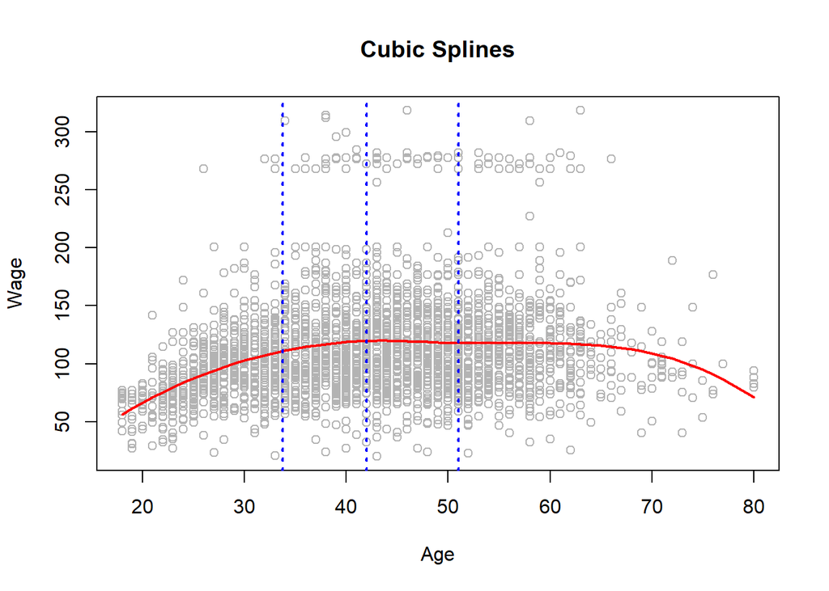

```r
lm.fit = lm(y ~ ., data = wage.dat)
o = order(wage.dat$x1)
plot(wage.dat$x1, wage.dat$y, col = "grey70", xlab = "Age",
     ylab = "Wage", main = "Cubic Splines")
lines(wage.dat$x1[o], lm.fit$fitted.values[o], col = "red", lwd = 2)
abline(v = quantile(wage.dat$x1, prob = c(0.25, 0.5, 0.75)), col = "blue", lty = 3, lwd = 2)
```

## 연습문제

### 9.1

```r
source("functions/mult_reg.R", echo = F)
x = c(6.4,16.1,42.1,2.1,30.7,32.1,7.2,3.4,20.8,1.5)
y = c(1.7,2.7,4.9,0.3,3.9,4.1,1.2,0.5,3.3,0.2)
x2 = x^2 ; X = cbind(x, x2)

mult_res = mult_reg(X, y, alpha = 0.05, coeff = TRUE)
```

```
##   요인     제곱합 자유도  평균제곱합      F값  F기각치
## 1 회귀 26.4882276      2 13.24411378 207.0444 4.737414
## 2 잔차  0.4477724      7  0.06396749       NA       NA
## 3   계 26.9360000      9          NA       NA       NA
## SST = 26.936, SSR = 26.4882275508065, SSE = 0.447772449193478
## MSR = 13.2441137754033, MSE = 0.0639674927419254
## F_0 = 207.044440976234, F_alpha = 4.73741412777588
```

```r
beta_hat = mult_res$beta_hat ; beta_hat
```

```
##             [,1]
## one  0.015805868
## x    0.193692401
## x2  -0.001937853
```

```r
## 축차 F 검정으로 삼차항 추가가 바람직한지 확인하기
x3 = x^3 ; X = cbind(X, x3)
mult_res = mult_reg(X, y, alpha = 0.05, coeff = TRUE) ; MSE = mult_res$MSE
```

```
##   요인     제곱합 자유도 평균제곱합      F값  F기각치
## 1 회귀 26.6726367      3 8.89087890 202.5539 4.757063
## 2 잔차  0.2633633      6 0.04389388       NA       NA
## 3   계 26.9360000      9         NA       NA       NA
## SST = 26.936, SSR = 26.6726367014552, SSE = 0.263363298544797
## MSR = 8.89087890048507, MSE = 0.0438938830907995
## F_0 = 202.553938599902, F_alpha = 4.75706266308942
```

```r
SS_beta3_beta012 = ASS_calc(X, y, index_sol = c(3), index_given = c(0,1,2), coef = TRUE)
```

```
## SS(beta_3 | beta_0, beta_1, beta_2) = 0.184409150650083
```

```r
F_0 = SS_beta3_beta012 / MSE ; F_alpha = qf(0.05, 1, 6, lower.tail = FALSE)
F_0 ; F_alpha
```

```
##          [,1]
## [1,] 4.201249
```

```
## [1] 5.987378
```

```r
x = c(6.4,16.1,42.1,2.1,30.7,32.1,7.2,3.4,20.8,1.5)
y = c(1.7,2.7,4.9,0.3,3.9,4.1,1.2,0.5,3.3,0.2)
x2 = x^2 ; X = cbind(x, x2)

mult_res = mult_reg(X, y, alpha = 0.05, coeff = TRUE)
```

```
##   요인     제곱합 자유도  평균제곱합      F값  F기각치
## 1 회귀 26.4882276      2 13.24411378 207.0444 4.737414
## 2 잔차  0.4477724      7  0.06396749       NA       NA
## 3   계 26.9360000      9          NA       NA       NA
## SST = 26.936, SSR = 26.4882275508065, SSE = 0.447772449193478
## MSR = 13.2441137754033, MSE = 0.0639674927419254
## F_0 = 207.044440976234, F_alpha = 4.73741412777588
```

```r
beta_hat = mult_res$beta_hat ; beta_hat
```

```
##             [,1]
## one  0.015805868
## x    0.193692401
## x2  -0.001937853
```

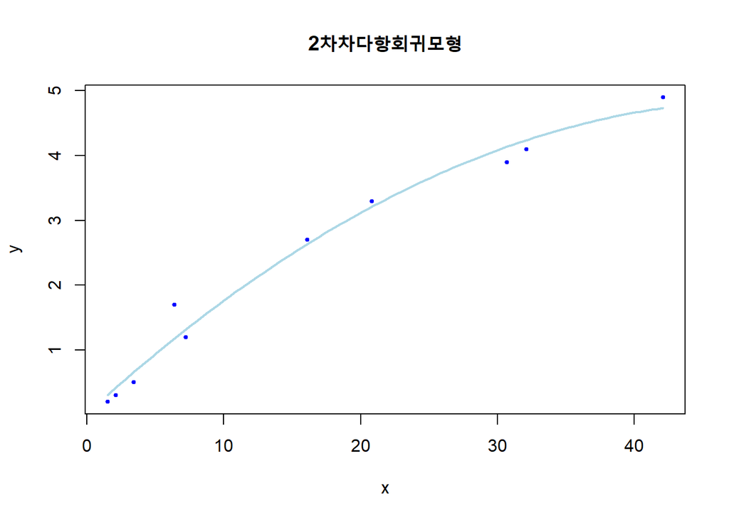

```r
plot(x, y, xlab = "x", ylab = "y", col = "blue", cex = 0.5, pch = 19,
     main = "2차차다항회귀모형")
# abline(coef = beta_hat_mult, lwd = 2, col = "red")
curve(beta_hat[1] + beta_hat[2] * x + beta_hat[3] * x^2 , n = 101, add = TRUE, col = "lightblue", lwd = 2)
```

### 9.2

```r
t1 = c(190, 190, 210, 210, 200, 185, 215, 200, 200)
t2 = c(75, 85, 75, 85, 80, 80, 80, 72.5, 87.5)
y = c(13.9, 13.1, 12.9, 13.6, 15.7, 11.8, 12.7, 12.0, 12.4)

x1 = (t1 - 200)/10 ; x2 = (t2 - 80)/5 ; X = cbind(x1, x2)
```

#### 9.2 - (1)

```r
mult_res = mult_reg(X, y, alpha = 0.05, coeff = TRUE)
```

```
##   요인     제곱합 자유도 평균제곱합        F값  F기각치
## 1 회귀  0.1144118      2 0.05720588 0.03086331 5.143253
## 2 잔차 11.1211438      6 1.85352397         NA       NA
## 3   계 11.2355556      8         NA         NA       NA
## SST = 11.2355555555555, SSR = 0.114411764705883, SSE = 11.1211437908496
## MSR = 0.0572058823529414, MSE = 1.8535239651416
## F_0 = 0.0308633087183047, F_alpha = 5.14325284978472
```

```r
beta_hat = mult_res$beta_hat ; beta_hat
```

```
##            [,1]
## one 13.12222222
## x1   0.10000000
## x2   0.05882353
```

#### 9.2 - (2)

```r
x1_2 = x1^2 ; x2_2 = x2^2 ; x12 = x1 * x2
X = cbind(X, x1_2, x2_2, x12)

mult_res = mult_reg(X, y, alpha = 0.05, coeff = TRUE)
```

```
##   요인    제곱합 자유도 평균제곱합      F값  F기각치
## 1 회귀  9.531091      5  1.9062183 3.355104 9.013455
## 2 잔차  1.704464      3  0.5681547       NA       NA
## 3   계 11.235556      8         NA       NA       NA
## SST = 11.2355555555555, SSR = 9.53109148133572, SSE = 1.70446407421993
## MSR = 1.90621829626714, MSE = 0.568154691406642
## F_0 = 3.35510438459588, F_alpha = 9.01345516752258
```

```r
beta_hat = mult_res$beta_hat ; beta_hat
```

```
##             [,1]
## one  15.88456376
## x1    0.10000000
## x2    0.05882353
## x1_2 -1.45130500
## x2_2 -1.47352722
## x12   0.37500000
```

#### 9.2 - (3)

```r
MSE = mult_res$MSE
SS_beta12_ = ASS_calc(X, y, index_sol = c(5), index_given = c(0,1,2,3,4), coef = TRUE)
```

```
## SS(beta_5 | beta_0, beta_1, beta_2, beta_3, beta_4) = 0.5625
```

```r
F_0 = SS_beta12_ / MSE ; F_alpha = qf(0.05, 1, 3, lower.tail = FALSE)
F_0 ; F_alpha
```

```
##           [,1]
## [1,] 0.9900473
```

```
## [1] 10.12796
```

#### 9.2 - (4)

```r
MSE = mult_res$MSE
XtX_inv = solve(mult_res$XtX) ; XtX_inv * MSE
```

```
##             one         x1         x2       x1_2       x2_2       x12
## one   0.5529022 0.00000000 0.00000000 -0.2592921 -0.2592921 0.0000000
## x1    0.0000000 0.06684173 0.00000000  0.0000000  0.0000000 0.0000000
## x2    0.0000000 0.00000000 0.06684173  0.0000000  0.0000000 0.0000000
## x1_2 -0.2592921 0.00000000 0.00000000  0.1653293  0.1092153 0.0000000
## x2_2 -0.2592921 0.00000000 0.00000000  0.1092153  0.1653293 0.0000000
## x12   0.0000000 0.00000000 0.00000000  0.0000000  0.0000000 0.1420387
```

#### 9.2 - (5)

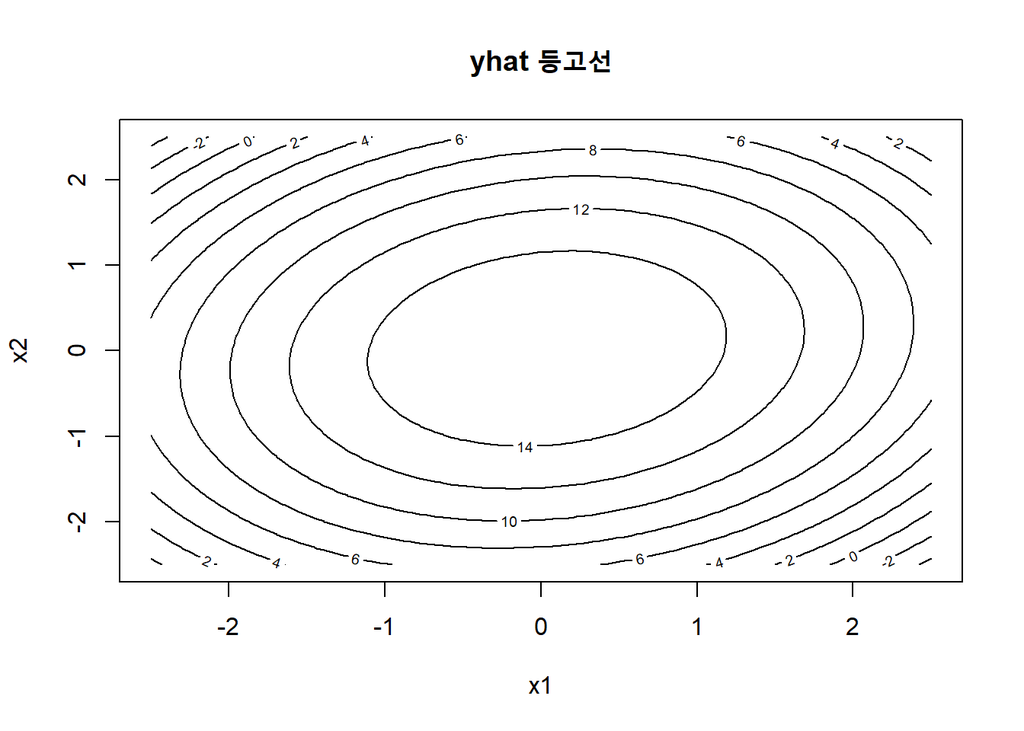

```r
# x1, x2의 범위 설정 (데이터에 따라 적절한 범위 선택; 여기서는 -1.5 ~ 1.5로 예시)
x1.seq <- seq(-2.5, 2.5, length = 100)
x2.seq <- seq(-2.5, 2.5, length = 100)

# x1, x2의 조합으로 grid 생성
grid <- expand.grid(x1 = x1.seq, x2 = x2.seq)

# 각 grid 점에서의 ŷ 계산
grid$yhat <- with(grid,
  beta_hat[1] + beta_hat[2] * x1 + beta_hat[3] * x2 + beta_hat[4] * x1^2 + beta_hat[5] * x2^2 + beta_hat[6] * x1 * x2
)

# ŷ 값을 matrix 형태로 변환 (행: x1, 열: x2)
yhat.mat <- matrix(grid$yhat, nrow = length(x1.seq), ncol = length(x2.seq))

# 등고선 그리기
contour(x1.seq, x2.seq, yhat.mat,
        xlab = "x1", ylab = "x2",
        main = "yhat 등고선")
```

### 9.3

```r
x = c(100, 110, 120, 130, 140, 150, 160, 170)
y = c(20, 24, 27, 28, 29, 29, 28, 27)

X = cbind(x)
```

### 9.3 - (1)

```r
X_p = ortho_poly(X, k = 2, coef = TRUE)

X_p = X_p[, -c(1)]

mult_res = mult_reg(X_p, y, alpha = 0.05, coeff = TRUE) ; MSE = mult_res$MSE
```

```
##   요인     제곱합 자유도 평균제곱합      F값  F기각치
## 1 회귀 65.2380952      2  32.619048 214.0625 5.786135
## 2 잔차  0.7619048      5   0.152381       NA       NA
## 3   계 66.0000000      7         NA       NA       NA
## SST = 66, SSR = 65.2380952380953, SSE = 0.761904761904724
## MSR = 32.6190476190477, MSE = 0.152380952380945
## F_0 = 214.062500000011, F_alpha = 5.78613504334997
```

```r
SS_beta1_02 = ASS_calc(X_p, y, index_sol = c(1), index_given = c(0,2), coef = TRUE)
```

```
## SS(beta_1 | beta_0, beta_2) = 34.3809523809514
```

```r
SS_beta2_01 = ASS_calc(X_p, y, index_sol = c(2), index_given = c(0,1), coef = TRUE)
```

```
## SS(beta_2 | beta_0, beta_1) = 30.8571428571422
```

```r
SS_beta1_02 ; SS_beta2_01
```

```
##          [,1]
## [1,] 34.38095
```

```
##          [,1]
## [1,] 30.85714
```

```r
SS_beta1_02/MSE ; SS_beta2_01/MSE
```

```
##         [,1]
## [1,] 225.625
```

```
##       [,1]
## [1,] 202.5
```

```r
beta_hat = mult_res$beta_hat ; beta_hat
```

```
##           [,1]
## one 26.5000000
## x^1  0.9047619
## x^2 -0.4285714
```

```r
F_alpha_1 = qf(0.05, 1, 5, lower.tail = FALSE) ; F_alpha_1
```

```
## [1] 6.607891
```

### 9.3 - (2)

```r
X_p_3 = ortho_poly(X, k = 3, coef = TRUE)

X_p_3 = X_p_3[, -c(1)]

mult_res = mult_reg(X_p_3, y, alpha = 0.05, coeff = TRUE) ; MSE = mult_res$MSE
```

```
##   요인     제곱합 자유도  평균제곱합      F값  F기각치
## 1 회귀 65.7835498      3 21.92784993 405.2267 6.591382
## 2 잔차  0.2164502      4  0.05411255       NA       NA
## 3   계 66.0000000      7          NA       NA       NA
## SST = 66, SSR = 65.7835497835498, SSE = 0.216450216450323
## MSR = 21.9278499278499, MSE = 0.0541125541125809
## F_0 = 405.226666666466, F_alpha = 6.59138211642558
```

```r
SS_beta1_023 = ASS_calc(X_p_3, y, index_sol = c(1), index_given = c(0,2,3), coef = TRUE)
```

```
## SS(beta_1 | beta_0, beta_2, beta_3) = 34.3809523809523
```

```r
SS_beta2_013 = ASS_calc(X_p_3, y, index_sol = c(2), index_given = c(0,1,3), coef = TRUE)
```

```
## SS(beta_2 | beta_0, beta_1, beta_3) = 30.8571428571431
```

```r
SS_beta3_012 = ASS_calc(X_p_3, y, index_sol = c(3), index_given = c(0,1,2), coef = TRUE)
```

```
## SS(beta_3 | beta_0, beta_1, beta_2) = 0.545454545455868
```

```r
SS_beta1_023 ; SS_beta2_013 ; SS_beta3_012
```

```
##          [,1]
## [1,] 34.38095
```

```
##          [,1]
## [1,] 30.85714
```

```
##           [,1]
## [1,] 0.5454545
```

```r
SS_beta1_023/MSE ; SS_beta2_013/MSE ; SS_beta3_012/MSE
```

```
##        [,1]
## [1,] 635.36
```

```
##        [,1]
## [1,] 570.24
```

```
##       [,1]
## [1,] 10.08
```

```r
beta_hat = mult_res$beta_hat ; beta_hat
```

```
##            [,1]
## one 26.50000000
## x^1  0.90476190
## x^2 -0.42857143
## x^3  0.03030303
```

```r
F_alpha_1 = qf(0.05, 1, 4, lower.tail = FALSE) ; F_alpha_1
```

```
## [1] 7.708647
```

```r
## 4차항도 필요한지 검토
X_p_4 = ortho_poly(X, k = 4, coef = TRUE)

X_p_4 = X_p_4[, -c(1)]

mult_res = mult_reg(X_p_4, y, alpha = 0.05, coeff = TRUE) ; MSE = mult_res$MSE
```

```
##   요인     제곱합 자유도  평균제곱합      F값  F기각치
## 1 회귀 65.7900433      4 16.44751082 235.0129 9.117182
## 2 잔차  0.2099567      3  0.06998557       NA       NA
## 3   계 66.0000000      7          NA       NA       NA
## SST = 66, SSR = 65.7900432900434, SSE = 0.209956709956616
## MSR = 16.4475108225108, MSE = 0.0699855699855385
## F_0 = 235.012886598044, F_alpha = 9.11718225324642
```

```r
SS_beta1_0234 = ASS_calc(X_p_4, y, index_sol = c(1), index_given = c(0,2,3,4), coef = TRUE)
```

```
## SS(beta_1 | beta_0, beta_2, beta_3, beta_4) = 34.3809523809523
```

```r
SS_beta2_0134 = ASS_calc(X_p_4, y, index_sol = c(2), index_given = c(0,1,3,4), coef = TRUE)
```

```
## SS(beta_2 | beta_0, beta_1, beta_3, beta_4) = 30.8571428571431
```

```r
SS_beta3_0124 = ASS_calc(X_p_4, y, index_sol = c(3), index_given = c(0,1,2,4), coef = TRUE)
```

```
## SS(beta_3 | beta_0, beta_1, beta_2, beta_4) = 0.54545454545314
```

```r
SS_beta4_0123 = ASS_calc(X_p_4, y, index_sol = c(4), index_given = c(0,1,2,3), coef = TRUE)
```

```
## SS(beta_4 | beta_0, beta_1, beta_2, beta_3) = 0.00649350649291591
```

```r
SS_beta1_0234 ; SS_beta2_0134 ; SS_beta3_0124 ; SS_beta4_0123
```

```
##          [,1]
## [1,] 34.38095
```

```
##          [,1]
## [1,] 30.85714
```

```
##           [,1]
## [1,] 0.5454545
```

```
##             [,1]
## [1,] 0.006493506
```

```r
SS_beta1_0234/MSE ; SS_beta2_0134/MSE ; SS_beta3_0124/MSE ; SS_beta4_0123/MSE
```

```
##          [,1]
## [1,] 491.2577
```

```
##          [,1]
## [1,] 440.9072
```

```
##          [,1]
## [1,] 7.793814
```

```
##            [,1]
## [1,] 0.09278351
```

```r
beta_hat = mult_res$beta_hat ; beta_hat
```

```
##             [,1]
## one 26.500000000
## x^1  0.904761905
## x^2 -0.428571429
## x^3  0.030303030
## x^4 -0.001893939
```

```r
F_alpha_1 = qf(0.05, 1, 3, lower.tail = FALSE) ; F_alpha_1
```

```
## [1] 10.12796
```

### 9.3 - (3)

```r
x = c(100, 110, 120, 130, 140, 150, 160, 170)
y = c(20, 24, 27, 28, 29, 29, 28, 27)

X = cbind(x)

X_p = ortho_poly(X, k = 2, coef = TRUE)

X_p = X_p[, -c(1)]

mult_res = mult_reg(X_p, y, alpha = 0.05, coeff = TRUE) ; MSE = mult_res$MSE
```

```
##   요인     제곱합 자유도 평균제곱합      F값  F기각치
## 1 회귀 65.2380952      2  32.619048 214.0625 5.786135
## 2 잔차  0.7619048      5   0.152381       NA       NA
## 3   계 66.0000000      7         NA       NA       NA
## SST = 66, SSR = 65.2380952380953, SSE = 0.761904761904724
## MSR = 32.6190476190477, MSE = 0.152380952380945
## F_0 = 214.062500000011, F_alpha = 5.78613504334997
```

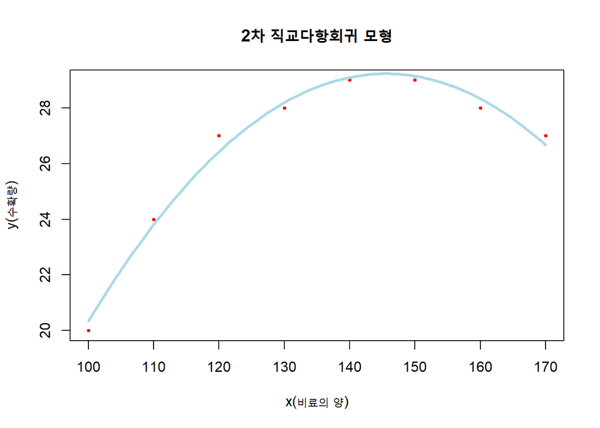

```r
beta_hat = mult_res$beta_hat

beta_0 = beta_hat[1] ; beta_1 = beta_hat[2] ; beta_2 = beta_hat[3]

plot(x, y, xlab = "x(비료의 양)", ylab = "y(수확량)", cex = 0.5, pch = 19,
     main = "2차 직교다항회귀 모형", col = "red")
curve(beta_hat[1] + beta_hat[2] * ((x-135)/10) + beta_hat[3] * (((x-135)/10)^2 - 63/12) , n = 101, add = TRUE, col = "lightblue", lwd = 3)
```

### 9.3 - (4)

```r
solve(mult_res$XtX) * MSE
```

```
##            one         x^1          x^2
## one 0.01904762 0.000000000 0.0000000000
## x^1 0.00000000 0.003628118 0.0000000000
## x^2 0.00000000 0.000000000 0.0009070295
```

## 9.4

```r
x = c(1, 1, 2, 2, 3, 3, 4, 4, 5, 5, 6, 6, 7, 7, 8, 8, 9, 9, 10, 10)
y = c(0.10, 0.09, 0.15, 0.16, 0.19, 0.19, 0.23, 0.22, 0.23, 0.24,
      0.25, 0.25, 0.27, 0.26, 0.28, 0.28, 0.28, 0.29, 0.30, 0.31)
```

### 9.4 - (1)

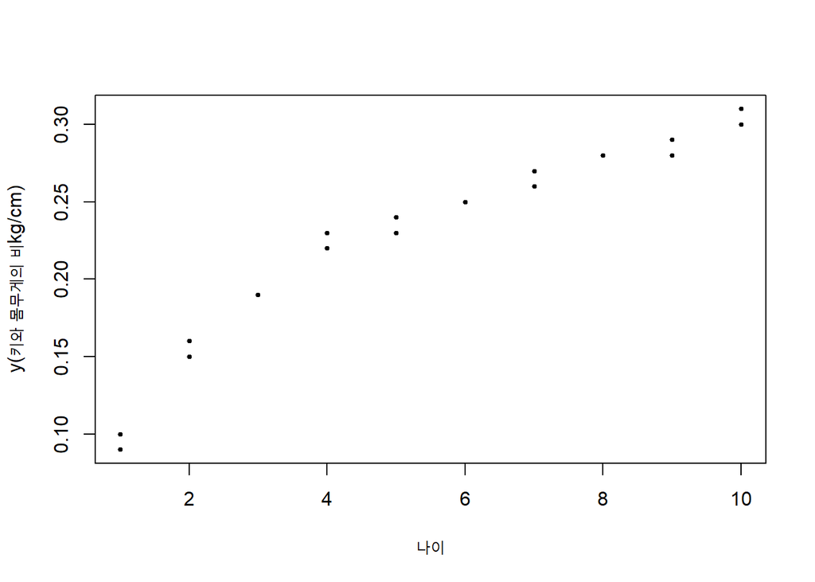

```r
plot(x, y, xlab = "나이", ylab = "y(키와 몸무게의 비kg/cm)", cex = 0.5, pch = 19)
```

### 9.4 - (2)

```r
n = length(x)
T1_x_4 = c(rep(1,n))
for (i in 1:n){
  if (x[i] - 4 < 0){
    T1_x_4[i] = 0
  }else{
    T1_x_4[i] = x[i] - 4
  }
}

X = cbind(x, T1_x_4)

mult_res_2 = mult_reg(X, y, alpha = 0.05, coeff = TRUE)
```

```
##   요인       제곱합 자유도   평균제곱합      F값  F기각치
## 1 회귀 0.0759788754      2 3.798944e-02 737.1331 3.591531
## 2 잔차 0.0008761246     17 5.153674e-05       NA       NA
## 3   계 0.0768550000     19           NA       NA       NA
## SST = 0.0768549999999999, SSR = 0.0759788753799341, SSE = 0.000876124620065872
## MSR = 0.037989437689967, MSE = 5.1536742356816e-05
## F_0 = 737.133081228654, F_alpha = 3.59153056847508
```

```r
beta_hat_2 = mult_res_2$beta_hat ; beta_hat_2
```

```
##               [,1]
## one     0.06223404
## x       0.04115957
## T1_x_4 -0.02862462
```

```r
SSR = mult_res_2$SSR ; SST = mult_res_2$SST
R2 = SSR/SST ; R2
```

```
## [1] 0.9886003
```

### 9.4 - (3), (4)

```r
T2_x_4 = T1_x_4^2
X = cbind(x, T2_x_4)

mult_res_3 = mult_reg(X, y, alpha = 0.05, coeff = TRUE) ; beta_hat_3 = mult_res_3$beta_hat
```

```
##   요인      제곱합 자유도   평균제곱합      F값  F기각치
## 1 회귀 0.073764488      2 0.0368822442 202.8784 3.591531
## 2 잔차 0.003090512     17 0.0001817948       NA       NA
## 3   계 0.076855000     19           NA       NA       NA
## SST = 0.0768549999999999, SSR = 0.0737644883485301, SSE = 0.00309051165146989
## MSR = 0.036882244174265, MSE = 0.00018179480302764
## F_0 = 202.878429746187, F_alpha = 3.59153056847508
```

```r
beta_hat_3 ; R2 = mult_res_3$SSR / mult_res_3$SST ; R2
```

```
##               [,1]
## one     0.08670213
## x       0.03006028
## T2_x_4 -0.00258612
```

```
## [1] 0.9597878
```

### 9.4 - (5)

```r
x2 = x^2 ; X = cbind(x, x2)

mult_res_5 = mult_reg(X, y, alpha = 0.05, coeff = TRUE) ; beta_hat_5 = mult_res_5$beta_hat
```

```
##   요인      제곱합 자유도  평균제곱합      F값  F기각치
## 1 회귀 0.074898333      2 0.037449167 325.3675 3.591531
## 2 잔차 0.001956667     17 0.000115098       NA       NA
## 3   계 0.076855000     19          NA       NA       NA
## SST = 0.0768549999999999, SSR = 0.0748983333333409, SSE = 0.00195666666665906
## MSR = 0.0374491666666704, MSE = 0.000115098039215239
## F_0 = 325.36754684968, F_alpha = 3.59153056847508
```

```r
beta_hat_5 ; R2 = mult_res_5$SSR/ mult_res_5$SST ; R2
```

```
##             [,1]
## one  0.065666667
## x    0.045515152
## x2  -0.002272727
```

```
## [1] 0.9745408
```

### 9.4 - (6)

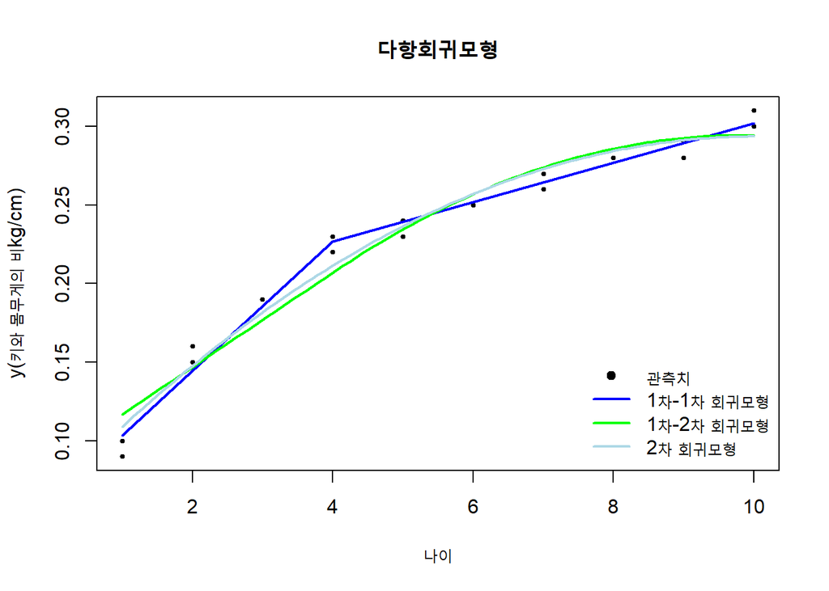

```r
plot(x, y, xlab = "나이", ylab = "y(키와 몸무게의 비kg/cm)",
     main = "다항회귀모형", cex = 0.5, pch = 19)

# 접합점 전 구간: x < 4
x_min <- min(x)    # 예: 1
x_knot <- 4
y_min <- beta_hat_2[1] + beta_hat_2[2] * x_min
y_knot <- beta_hat_2[1] + beta_hat_2[2] * x_knot

segments(x_min, y_min, x_knot, y_knot, col = "blue", lwd = 2)

# 접합점 후 구간: x >= 4
x_max <- max(x)    # 예: 10
# x>=4인 구간의 회귀식은 y = beta_hat_2[1] + beta_hat_2[2]*x + beta_hat_2[3]*(x - 4)
y_knot2 <- beta_hat_2[1] + beta_hat_2[2] * x_knot  # x=4에서의 y값 (두 식이 같아야 함)
y_max <- beta_hat_2[1] + beta_hat_2[2] * x_max + beta_hat_2[3] * (x_max - 4)

segments(x_knot, y_knot2, x_max, y_max, col = "blue", lwd = 2)

curve(ifelse(x < 4,
             beta_hat_3[1] + beta_hat_3[2] * x,
             beta_hat_3[1] + beta_hat_3[2] * x + beta_hat_3[3] * (x - 4)^2),
      from = min(x), to = max(x), n = 101, add = TRUE, col = "green", lwd = 2)
curve(beta_hat_5[1] + beta_hat_5[2] * x + beta_hat_5[3] * x^2,
      from = min(x), to = max(x), n = 101, add = TRUE, col = "lightblue", lwd = 2)

legend("bottomright",
       legend = c("관측치", "1차-1차 회귀모형", "1차-2차 회귀모형", "2차 회귀모형"),
       col = c("black", "blue", "green", "lightblue"),
       pch = c(19, NA, NA, NA),
       lty = c(NA, 1, 1, 1),
       lwd = c(NA, 2, 2, 2),
       bty = "n")
```

### 9.10

```r
library(ISLR)
library(dplyr)
data(Auto)

dataset  = Auto %>% na.omit %>% select(horsepower,mpg)
x = dataset$horsepower ; y = dataset$mpg
```

#### 9.10 - (1)

```r
X = cbind(x);
mult_res = mult_reg(X, y, alpha = 0.05, coeff = TRUE)
```

```
##   요인    제곱합 자유도  평균제곱합      F값  F기각치
## 1 회귀 14433.078      1 14433.07760 599.7177 3.865413
## 2 잔차  9385.916    390    24.06645       NA       NA
## 3   계 23818.993    391          NA       NA       NA
## SST = 23818.9934693878, SSR = 14433.0775974554, SSE = 9385.91587193232
## MSR = 14433.0775974554, MSE = 24.0664509536726
## F_0 = 599.71774090159, F_alpha = 3.86541288694413
```

#### 9.10 - (2)

```r
x2 = x^2
X = cbind(x, x2);
mult_res = mult_reg(X, y, alpha = 0.05, coeff = TRUE)
```

```
##   요인    제곱합 자유도 평균제곱합      F값  F기각치
## 1 회귀 16376.964      2 8188.48203 428.0176 3.018922
## 2 잔차  7442.029    389   19.13118       NA       NA
## 3   계 23818.993    391         NA       NA       NA
## SST = 23818.9934693878, SSR = 16376.9640576047, SSE = 7442.02941178311
## MSR = 8188.48202880233, MSE = 19.1311810071545
## F_0 = 428.017592104746, F_alpha = 3.01892164402762
```